# **Third Attempt - The 2016 US Elections**

### **1. Project objective, Dataset, Tools and Libraries**

#### 1.1. Objective of the Project

Predict the winners of US presidential primaries in each of the US geographical units identified by Federal Information Processing Standards (FIPS) codes, typically (but not necessarily) a county. That is, based upon features encompassing demographical make-up and socio-economic status of the population in FIPS code area, we predict *which candidate across both parties will score highest number of votes in that FIPS code area during the presidential primaries across both parties*.

*Two important facts about this data and project goals:*

1. At the US State level, except for a few swing states, it is remarkably easy to predict the winner of a political election. But for a more basic geographical unit, such as the one identified by FIPS code, voter's political opinion should be a little more challenging. Furthermore, to make things interesting, I have decided to predict the particular candidate of *any* party who will score highest votes in a county. That is to say, machine learning model will not only have to account for differences between the fans of Donald Trump and Bernie Sanders (very easy) but also between fans of Donald Trump and Ted Cruz (a little more challenging).
2. **A CAVEAT**: More importantly, the two facts that, (**1**) in the early stages of presidential primaries, there are more candidates competing (specially in Republican primaries) than in the end, (**2**) the demographic features of States with late primaries can not account for dropped out primaries' candidates because samples are not arranged in time-series. (While we do engineer a new feature `Date of Primaries` by outsourcing information from Wikipedia to address this, *it will still impose a limitation on the machine learning model, which may affect classification accuracy*).

#### 1.2 Tools and Libraries

We will use the well-known sklearn library to build, train and tune the models, in Python programming language. We will use pandas to manipulate the dataset, using dataframe application programming interface (API). We will also utilise some other common Python libraries, such as numpy. We will build the project in Jupyter notebook.

#### 1.3 About the Dataset

This dataset was chosen to demonstrate working with raw data. It is not a part of any official Kaggle competition, but *was* contributed by members to the Kaggle and can be downloaded from Kaggle [here](https://www.kaggle.com/benhamner/2016-us-election/data). In its original form, dataset comprises of several files, many of them not related to the goals of this project. The files do not arrange feature and label columns properly, as we would have like them and we will do quite a bit of column computing, arranging, mixing and merging to get a dataset with which we can work.

We will download three files, the `county_facts.csv`, `primary_results.csv` and `county_facts_dictionary.csv`. The last file just provides names of columns of `county_facts.csv`, since they are quite long. The `primary_results.csv` file is in a format not very useful to us and we will manipulate to make it a column of `county_facts.csv` dataset.

Let us import pandas and load our files.

```python
!pip install -U -q PyDrive
from pydrive.auth import GoogleAuth
from pydrive.drive import GoogleDrive
from google.colab import auth
from oauth2client.client import GoogleCredentials

auth.authenticate_user()
gauth = GoogleAuth()
gauth.credentials = GoogleCredentials.get_application_default()
drive = GoogleDrive(gauth)
```

```python
from pydrive.drive import GoogleDrive

# Create GoogleDrive instance with authenticated GoogleAuth instance
drive = GoogleDrive(gauth)

# Auto-iterate through all files in the root folder.
file_list = drive.ListFile({'q': "'1YPxz_rbqCzy1OuCAmLyRypU3QUTQDegw' in parents and trashed=false"}).GetList()

# Let us print the list of files
for file in file_list:
  print('title: %s, id: %s' % (file['title'], file['id']))
```

```
title: Keras Grid Search Recrod.ipynb, id: 1dOIl1CURKMgRyiKBcpqG9tc9OnH6L9BR
title: The 2016 US Elections FINAL.ipynb, id: 1icwXh5WhmPdcdAvlSebS7xmhjYq2lfZo
title: SKLEARN - How to Run Search Over Number of Neuron.ipynb, id: 1Yzch56TQbV6_2s7sByDbS3x8JlffLc_u
title: pima-indians-diabetes.csv, id: 1hbCXvV0yvPSG3Y8sPBqaeHk0jxw1--Jl
title: geckodriver.log, id: 1GuPJ3NOy34ejfZhNgwAfLXv29O3lqSRT
title: county_facts_dictionary.csv, id: 1E92vczp9xYN_surw9Au152LzGjaCLiD_
title: primary_results.csv, id: 1iysfQEssxj3BWUBXxBO0jgUccqXTXIOB
title: The 2016 US Elections.ipynb, id: 1_ghLhntA6q1Wxf2CPdlxuW9W9m-fdcG_
title: county_facts.csv, id: 1JVP0z_ubHyZtM6m_iLN9KUMX3k-l7rEU
```

```python
county_facts_dl = drive.CreateFile({'id': '1JVP0z_ubHyZtM6m_iLN9KUMX3k-l7rEU'})
county_facts_dl.GetContentFile('county_facts.csv')

county_facts_dictionary_dl = drive.CreateFile({'id': '1E92vczp9xYN_surw9Au152LzGjaCLiD_'})
county_facts_dictionary_dl.GetContentFile('county_facts_dictionary.csv')

primary_results_dl = drive.CreateFile({'id': '1iysfQEssxj3BWUBXxBO0jgUccqXTXIOB'})
primary_results_dl.GetContentFile('primary_results.csv')
```

```python
import pandas as pd
county_facts = pd.read_csv("county_facts.csv")
columns = pd.read_csv("county_facts_dictionary.csv")
results = pd.read_csv("primary_results.csv")
```

We will use following function to display dataframs throughout this project (this function ensures are columns are displayed, as pandas tends to truncate columns).

```python
def printDF(array, rows=6):
    from IPython.display import display, HTML
    display(HTML(array.to_html(max_rows=rows)))
```

Let us view the first few rows of each of these files.

```python
printDF(county_facts)
```

|  | fips | area_name | state_abbreviation | PST045214 | PST040210 | PST120214 | POP010210 | AGE135214 | AGE295214 | AGE775214 | SEX255214 | RHI125214 | RHI225214 | RHI325214 | RHI425214 | RHI525214 | RHI625214 | RHI725214 | RHI825214 | POP715213 | POP645213 | POP815213 | EDU635213 | EDU685213 | VET605213 | LFE305213 | HSG010214 | HSG445213 | HSG096213 | … |
| --- | --- | --- | --- | --- | --- | --- | --- | --- | --- | --- | --- | --- | --- | --- | --- | --- | --- | --- | --- | --- | --- | --- | --- | --- | --- | --- | --- | --- | --- | --- |
| 0 | 0 | United States | NaN | 318857056 | 308758105 | 3.3 | 308745538 | 6.2 | 23.1 | 14.5 | 50.8 | 77.4 | 13.2 | 1.2 | 5.4 | 0.2 | 2.5 | 17.4 | 62.1 | 84.9 | 12.9 | 20.7 | 86.0 | 28.8 | 21263779 | 25.5 | 133957180 | 64.9 | 26.0 | … |
| 1 | 1000 | Alabama | NaN | 4849377 | 4780127 | 1.4 | 4779736 | 6.1 | 22.8 | 15.3 | 51.5 | 69.7 | 26.7 | 0.7 | 1.3 | 0.1 | 1.5 | 4.1 | 66.2 | 85.0 | 3.5 | 5.2 | 83.1 | 22.6 | 388865 | 24.2 | 2207912 | 69.7 | 15.9 | … |
| 2 | 1001 | Autauga County | AL | 55395 | 54571 | 1.5 | 54571 | 6.0 | 25.2 | 13.8 | 51.4 | 77.9 | 18.7 | 0.5 | 1.1 | 0.1 | 1.8 | 2.7 | 75.6 | 85.0 | 1.6 | 3.5 | 85.6 | 20.9 | 5922 | 26.2 | 22751 | 76.8 | 8.3 | … |
| ... | ... | ... | ... | ... | ... | ... | ... | ... | ... | ... | ... | ... | ... | ... | ... | ... | ... | ... | ... | ... | ... | ... | ... | ... | ... | ... | ... | ... | ... | … |
| 3192 | 56041 | Uinta County | WY | 20904 | 21118 | -1.0 | 21118 | 7.6 | 29.8 | 11.0 | 49.6 | 95.4 | 0.9 | 1.2 | 0.5 | 0.2 | 1.8 | 9.2 | 87.3 | 81.8 | 3.4 | 6.6 | 89.2 | 18.9 | 1359 | 20.4 | 8773 | 72.7 | 15.5 | … |
| 3193 | 56043 | Washakie County | WY | 8322 | 8533 | -2.5 | 8533 | 5.5 | 23.9 | 20.1 | 49.3 | 94.8 | 0.8 | 1.7 | 0.7 | 0.1 | 1.8 | 13.9 | 82.7 | 88.0 | 5.0 | 10.4 | 90.5 | 23.6 | 752 | 12.4 | 3810 | 71.7 | 10.2 | … |
| 3194 | 56045 | Weston County | WY | 7201 | 7208 | -0.1 | 7208 | 6.5 | 21.6 | 18.1 | 47.4 | 95.0 | 0.7 | 1.7 | 0.4 | 0.0 | 2.2 | 4.2 | 91.5 | 88.7 | 0.4 | 1.7 | 90.2 | 17.2 | 773 | 28.6 | 3500 | 76.1 | 7.5 | … |

```python
printDF(columns, rows= 10)
```

|  | column_name | description |
| --- | --- | --- |
| 0 | PST045214 | Population, 2014 estimate |
| 1 | PST040210 | Population, 2010 (April 1) estimates base |
| 2 | PST120214 | Population, percent change - April 1, 2010 to July 1, 2014 |
| 3 | POP010210 | Population, 2010 |
| 4 | AGE135214 | Persons under 5 years, percent, 2014 |
| ... | ... | ... |
| 46 | RTN131207 | Retail sales per capita, 2007 |
| 47 | AFN120207 | Accommodation and food services sales, 2007 ($1,000) |
| 48 | BPS030214 | Building permits, 2014 |
| 49 | LND110210 | Land area in square miles, 2010 |
| 50 | POP060210 | Population per square mile, 2010 |

```python
printDF(results)
```

|  | state | state_abbreviation | county | fips | party | candidate | votes | fraction_votes |
| --- | --- | --- | --- | --- | --- | --- | --- | --- |
| 0 | Alabama | AL | Autauga | 1001.0 | Democrat | Bernie Sanders | 544 | 0.182 |
| 1 | Alabama | AL | Autauga | 1001.0 | Democrat | Hillary Clinton | 2387 | 0.800 |
| 2 | Alabama | AL | Baldwin | 1003.0 | Democrat | Bernie Sanders | 2694 | 0.329 |
| ... | ... | ... | ... | ... | ... | ... | ... | ... |
| 24608 | Wyoming | WY | Uinta-Lincoln | 95600027.0 | Republican | John Kasich | 0 | 0.000 |
| 24609 | Wyoming | WY | Uinta-Lincoln | 95600027.0 | Republican | Marco Rubio | 0 | 0.000 |
| 24610 | Wyoming | WY | Uinta-Lincoln | 95600027.0 | Republican | Ted Cruz | 53 | 1.000 |

### **2. Cleaning and Manipulation of Datasets**

In its raw form, this set comprises of multiple files with required information scattered around. We will perform a series of steps for data cleansing and preparation steps.

#### 2.1 Fixing `NaN` values

We start by checking the number of missing entries in the two datasets (third files provides list of columns). Here is the subset of `county_facts` dataframe which has `NaN` in *any* row.

```python
county_facts_nan = county_facts[county_facts.isnull().any(axis=1)]
```

It can be easily inspected by printing out `county_facts_nan` that all the rows with missing values have missing value in column `State`. This is because, while most rows are reporting data for `FIPS` code areas, a few rows are for aggregates for States and US national data, and that is where `area_name` column suffices, so no State is listed (i.e., since this is not a result for FIPS code area, there is no need to say in which State this FIPS code area is located). This can be verified by counting rows of `county_facts_nan` and rows where `State` is missing, as done below:

```python
print(len(county_facts_nan))
print(len(county_facts_nan.loc[county_facts_nan['state_abbreviation'].isnull()]))
```

```
52
52
```

```python
county_facts.loc[[1],'state_abbreviation'] = "AL"
county_facts = county_facts.dropna()
```

Let us double check if there are any other missing values.

```python
county_facts.isnull().values.any()
```

```
False
```

That was simple.

We also need to check for the `NAN` in `results` dataframe.

```python
results_nan = results[results.isnull().any(axis=1)]
printDF(results_nan)
```

|  | state | state_abbreviation | county | fips | party | candidate | votes | fraction_votes |
| --- | --- | --- | --- | --- | --- | --- | --- | --- |
| 14587 | New Hampshire | NH | Belknap | NaN | Democrat | Bernie Sanders | 5990 | 0.631857 |
| 14588 | New Hampshire | NH | Belknap | NaN | Democrat | Hillary Clinton | 3490 | 0.368143 |
| 14589 | New Hampshire | NH | Carroll | NaN | Democrat | Bernie Sanders | 5655 | 0.636466 |
| ... | ... | ... | ... | ... | ... | ... | ... | ... |
| 14684 | New Hampshire | NH | Sullivan | NaN | Republican | John Kasich | 1334 | 0.164997 |
| 14685 | New Hampshire | NH | Sullivan | NaN | Republican | Marco Rubio | 895 | 0.110699 |
| 14686 | New Hampshire | NH | Sullivan | NaN | Republican | Ted Cruz | 951 | 0.117625 |

A quick glance at `NAN` subset of `results`, the `results_nan` printed above, shows the missing values are in `fips` column and appear to be confined to when `state` is `New Hampshire`. Let us double check this by printing the number of missing values and the number of missing values where the state is `New Hampshire`.

```python
print(len(results_nan))
print(len(results_nan.loc[results_nan['state'] == 'New Hampshire']))
```

```
100
100
```

So we don't have `FIPS` code for `New Hampshire`. Luckily, the dataframe `county_facts` does list `FIPS` for `New Hampshire`. We can fill in the missing values for `fips` column in the `result` from corresponding values in the `FIPS` column in the `county_facts`. This is not as simple as it seems and is achieved in the following three cells.

```python
# Fetch part of 'results' df where state is NH
NH_results = results.loc[results['state_abbreviation'] == 'NH']

# Fetch 'unique' counties in NH as listed in 'results' dataframe
NH_unique_counties = NH_results['county'].unique()

# Fetch NH counties listed in 'county_facts' dataframe (they are already unique)
NH_county = county_facts.loc[county_facts['state_abbreviation'] == 'NH']
```

Now we will fetch the FIPS code for each county and build a look-up dictionary.

```python
NH_fips = []
for county in NH_unique_counties:
    # Since county name in 'county_facts' df is appended by word 'County', we fix county name
    county_name = county + " County"
    current = NH_county.loc[NH_county['area_name'] == county_name]
    NH_fips.append(int(current['fips']))

# Create lookup dictionary for NH county name and FIPS code
lookup = dict(zip(NH_unique_counties, NH_fips))
```

And finally, we will insert missing `fips` codes for `New Hampshire` counties into the `results` dataframe.

```python
# Since all missing fips are in NH, no need to check for state
for c in NH_unique_counties:
    results.loc[results['county'] == c, 'fips'] = lookup[c]
```

Remember, we had kind of *assumed* all missing values were in FIPS column (as there were some hints suggesting it), so before proceeding to next step, let us be sure there are no missing values in `results`.

```python
results.isnull().values.any()
```

```
False
```

#### 2.2 Fixing Data Type of `fips` Column in `results` Dataframe

FIPS is a code for a given county or area unit and should not be in `float` datatype. But a lot of the `fips` values are in `float` datatype (looking at the head of `result` above confirms this). We will convert them to `int` below.

```python
results['fips'] = results['fips'].astype(int)
```

#### 2.3 Fixing names of columns:

The head of `county_facts.csv` revealed some very cryptic columns names, which are later elaborated in `county_facts_dictionary.csv`. We will use the second file to rename the columns of first file. In the following, we create full list of columns names and then apply it to `county_facts` dataframe.

```python
# The first three columns do not have cryptic names
first_three_columns = ['FIPS', 'County', 'State']

new_names = first_three_columns + columns['description'].values.tolist()

# Apply these column names to 'county_facts'
county_facts.columns = new_names
```

#### 2.4 Incorporating 'Labels' into the 'Features' Dataframe

As we mentioned in the start, the format of `results` is in such a way that we cannot just paste elections results into the feature dataset `county_facts`. In particular, `results` has one row per candidate per FIPS area (so multiple rows per FIPS area), as opposed to one row per FIPS area in `county_facts`. This can be verified by comparing the number of rows in `county_facts` and `results` dataframes, the latter has way more rows.

```python
print("Number of rows in 'county_facts': ", len(county_facts))
print("Number of rows in 'results': ", len(results))
```

```
Number of rows in 'county_facts':  3144
Number of rows in 'results':  24611
```

This can be further elaborated, for example, by printing elections results for FIPS code `55097` in `Wisconsin`, as done below.

```python
results.loc[results['state']=='Wisconsin'].loc[results['fips']==55097]
```

|  | state | state_abbreviation | county | fips | party | candidate | votes | fraction_votes |
| --- | --- | --- | --- | --- | --- | --- | --- | --- |
| 24255 | Wisconsin | WI | Portage | 55097 | Democrat | Bernie Sanders | 9348 | 0.647 |
| 24256 | Wisconsin | WI | Portage | 55097 | Democrat | Hillary Clinton | 5036 | 0.349 |
| 24448 | Wisconsin | WI | Portage | 55097 | Republican | Donald Trump | 5112 | 0.402 |
| 24449 | Wisconsin | WI | Portage | 55097 | Republican | John Kasich | 1361 | 0.107 |
| 24450 | Wisconsin | WI | Portage | 55097 | Republican | Ted Cruz | 5866 | 0.462 |

```python
len(results['candidate'].unique())
```

```
16
```

But even if we account for above, there are still more *unique* FIPS in `results` then in `county_facts`, as shown below.

```python
fips_results = results['fips'].unique()
fips_county_facts = county_facts['FIPS'].unique()

print("FIPS in results: ", len(fips_results))
print("FIPS in county facts: ", len(fips_county_facts))
```

```
FIPS in results:  4189
FIPS in county facts:  3144
```

From machine learning point of view, if we don't have 'county facts' (features) for a 'vote result' (label), that particular 'result' is not very useful (it is not even *un*labeled data). So we will obviously ignore FIPS in `results` dataframe which do not exits in `county_facts`. How about converse of it; are all FIPS in `county_facts` available in `results`? Let us check.

```python
missing_fips = list(set(fips_county_facts) - set(fips_results))
len(missing_fips)
```

```
357
```

Turns out, no; we don't have results for *all* the FIPS in `county_facts` dataset, so we need to remove these rows from `county_facts` dataframe. This is accomplished below.

```python
county_facts = county_facts[~county_facts['FIPS'].isin(missing_fips)]

# We need to redefine list of FIPS in county facts now, as county_facts has changed
fips_county_facts = county_facts['FIPS'].unique()
```

Now we will loop through unique FIPS in `results`, find the winner of each FIPS amongst *all* candidates from all the parties by counting the votes and we will create new column in `county_facts` where we insert the winner of the FIPS.

All of this is accomplished in following cell.

```python
fips_winner = []

for f in fips_results:
    current = results[results['fips'] == f]
    max_votes = current['votes'].max()
    winner = current.loc[current['votes'] == max_votes]
    # In rare cases, two candidate have equal highest votes,
    # so we just pick FIRST one as the winner
    winner=winner.head(1)
    winner_candidate = winner['candidate'].item()
    fips_winner.append(winner_candidate)

winner_lookup = dict(zip(fips_results, fips_winner))

for f in fips_county_facts:
    county_facts.loc[county_facts['FIPS']==f,'Winner'] = winner_lookup[f]
```

#### 2.5 Fixing State names (Optional Step)

Personally I am not a fan of abbreviations, so I will rename the State abbreviations to full names of States. I found a nice dictionary on [Github](https://gist.github.com/rogerallen/1583593), which will save us the labour of creating one ourselves. Within next cell, we rename the entries in `State` by replacing abbreviations with full names.

```python
us_state_abbrev = {'AL': 'Alabama', 'AK': 'Alaska', 'AZ': 'Arizona', 'AR': 'Arkansas', 'CA': 'California',
                   'CO': 'Colorado', 'CT': 'Connecticut', 'DE': 'Delaware', 'FL': 'Florida', 'GA': 'Georgia',
                   'HI': 'Hawaii', 'ID': 'Idaho', 'IL': 'Illinois', 'IN': 'Indiana', 'IA': 'Iowa', 'KS': 'Kansas',
                   'KY': 'Kentucky', 'LA': 'Louisiana', 'ME': 'Maine', 'MD': 'Maryland', 'MA': 'Massachusetts',
                   'MI': 'Michigan', 'MN': 'Minnesota', 'MS': 'Mississippi', 'MO': 'Missouri', 'MT': 'Montana',
                   'NE': 'Nebraska', 'NV': 'Nevada', 'NH': 'New Hampshire', 'NJ': 'New Jersey', 'NM': 'New Mexico',
                   'NY': 'New York', 'NC': 'North Carolina', 'ND': 'North Dakota', 'OH': 'Ohio', 'OK': 'Oklahoma',
                   'OR': 'Oregon', 'PA': 'Pennsylvania', 'RI': 'Rhode Island', 'SC': 'South Carolina',
                   'SD': 'South Dakota', 'TN': 'Tennessee', 'TX': 'Texas', 'UT': 'Utah', 'VT': 'Vermont',
                   'VA': 'Virginia', 'WA': 'Washington', 'WV': 'West Virginia', 'WI': 'Wisconsin', 'WY': 'Wyoming'}

county_facts["State"] = county_facts["State"].apply(lambda x: us_state_abbrev[x])
```

```python
data = county_facts.copy()
```

### **3. Train-Test Split**

Next, we split the our full data into train and test subsets. The Scikit-Learn provides a handy function for that.

```python
X = data.drop('Winner', axis = 1)
y = data['Winner'].values
```

```python
from sklearn.model_selection import train_test_split

X_train, X_test, y_train, y_test = train_test_split(X, y , test_size = 0.20 , random_state = 1952)

X_train = pd.DataFrame(X_train).reset_index().drop(['index'],axis=1)
X_test  = pd.DataFrame(X_test ).reset_index().drop(['index'],axis=1)
y_train = pd.DataFrame(y_train, columns=['Winner']).reset_index().drop(['index'],axis=1)
y_test  = pd.DataFrame(y_test,  columns=['Winner']).reset_index().drop(['index'],axis=1)
```

During the visualisation and data exploration, it will be handing to features and label in on dataframe:

```python
train = pd.concat([X_train, y_train], axis=1)
```

### **4. Visualisation and Exploratory Analysis**

Now that our data is in a proper format with columns and labels, we can perform visualisation and exploratory analysis. This will help us get an idea of trends as to what influences the chances of winning the election and hence forth, give us an idea of what kind of features to engineer.

#### **4.1 Checking for Class Imbalance in Label**

As noted earlier, this is a multi-class classification project and it is likely that there is class-imbalance in the dataset. Let us check the distribution of population in our label `Winner`:

```python
def print_class_dist(vector):
    temp = pd.DataFrame(vector)
    temp.columns = ["Classes"]
    temp = pd.DataFrame(temp["Classes"].value_counts())
    temp.columns=["Counts"]
    percent_collector = []
    for idx in list(temp.index):
        percent_collector.append(str(round(temp["Counts"][idx]/len(vector)*100, 2))+"%")
    temp["Winner"] = percent_collector
    print(temp)

print_class_dist(train["Winner"])
```

```
                 Counts  Winner
Donald Trump       1103  49.48%
Hillary Clinton     448   20.1%
Ted Cruz            342  15.34%
Bernie Sanders      289  12.97%
John Kasich          42   1.88%
Marco Rubio           5   0.22%
```

But before we get to plotting, let us quickly see which candidate won how many FIPS area codes?

```python
FIPS_winner = train.groupby('Winner').count()['FIPS']
pd.DataFrame(FIPS_winner).sort_values('FIPS',ascending=False)
```

| Winner | FIPS |
| --- | --- |
| Donald Trump | 1103 |
| Hillary Clinton | 448 |
| Ted Cruz | 342 |
| Bernie Sanders | 289 |
| John Kasich | 42 |
| Marco Rubio | 5 |

Turns out, Trump actually won more FIPS areas than Clinton and Sanders *combined*. While we are at it, let us store the list of winning candidates, who won at least one FIPS code area.

```python
winning_candidates = train['Winner'].unique().tolist()
```

**We will balance the classes after the exploration of data**.

#### **4.2 Visualising Some General Trends**

We will us the popular `seaborn` library for visualisation. Let us import it along with `matplotlib.pyplot` and execute the `matplotlib` magic command.

```python
import seaborn as sns
import matplotlib.pyplot as plt
%matplotlib inline
```

Since the **`FacetGrid`** plot is useful when we have to visualise the distribution of one or more variables within subsets of dataset, it will be ideal for our project, as we would be interested to know the distribution of various socio-economic indicators in counties where each candidate won.

Since it is widely believed that the elections results in the United States depend significantly on racial and ethnic make-up of relevant geographical unit, let us see the distribution of various racial groups in the counties where each candidate won. First, let us use `FacetGrid` for the distribution of `White alone, not Hispanic or Latino, percent, 2014`, in counties where each candidate won.

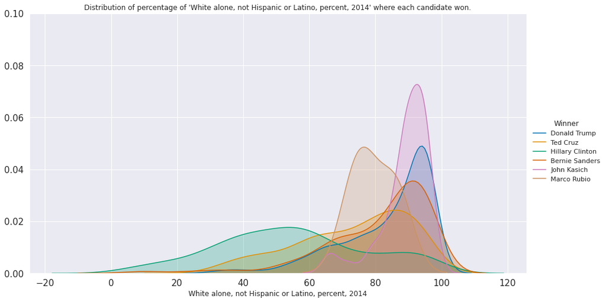

```python
sns.set(font_scale=2.5)
sns.set(rc={'figure.figsize':(15,10)})
fig = sns.FacetGrid(train, hue="Winner", height= 7, aspect=1.8, palette="colorblind")
fig.map(sns.kdeplot,'White alone, not Hispanic or Latino, percent, 2014',shade= True)
fig.set(ylim=(0, 0.1))
fig.add_legend()
fig.set_yticklabels(size=15)
fig.set_xticklabels(size=15)
plt.title('Distribution of percentage of \'White alone, not Hispanic or Latino, percent, 2014\' '\
           'where each candidate won.')
plt.show()
```

Candidate Hillary Clinton won more counties where the percentage of `White alone, not Hispanic or Latino, percent, 2014` was around `50%`-`60%` but she did won some where percentage was between `80`-`100`, as indicated by a smaller second plateau. John Kasich was most likely to win counties where the percentage of `White alone, not Hispanic or Latino, percent, 2014` was close to `100%`. Although Donald Trump's distribution peaks further towards the right compared to Clinton, it is fairly widely distributed throughout the percentage spectrum, with he being winer in some counties where percentage of `White alone, not Hispanic or Latino, percent, 2014` was around `60%`.

Let us check the same for `Black or African American alone, percent, 2014`.

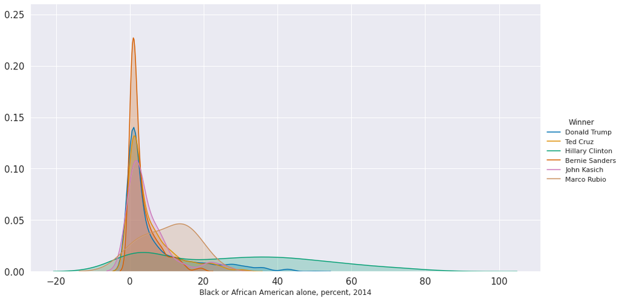

```python
sns.set(font_scale=2.5)
sns.set(rc={'figure.figsize':(15,10)})
fig = sns.FacetGrid(train, hue="Winner", height= 7, aspect=1.8, palette="colorblind")
fig.map(sns.kdeplot,'Black or African American alone, percent, 2014',shade= True)
fig.set(ylim=(0, 0.26))
fig.add_legend()
fig.set_yticklabels(size=15)
fig.set_xticklabels(size=15)
plt.show()
```

The lack of Bernie Sanders support amongst the `Black or African American alone, percent, 2014` is truly remarkable, with a tall peak near `0%`. *All other feactors being equal*, looks like Clinton and Rubio enjoyed support of African Americans the most but Rubio won so few counties because all other factors were not equal.

Let us check the same for `Asian alone, percent, 2014`.

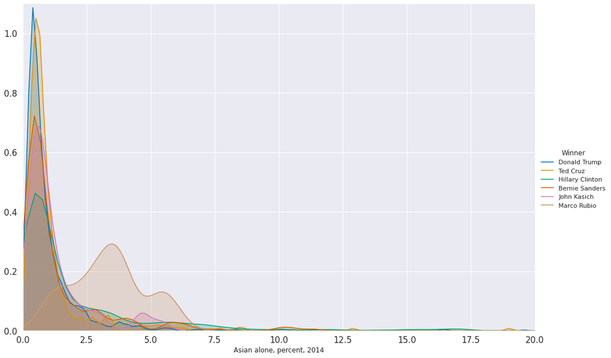

```python
sns.set(font_scale=2.5)
sns.set(rc={'figure.figsize':(15,10)})
fig = sns.FacetGrid(train, hue="Winner", height= 9, aspect=1.5, palette="colorblind")
fig.map(sns.kdeplot,'Asian alone, percent, 2014',shade= True)
#oldest = train['Age'].max()
fig.set(ylim=(0, 1.1))
fig.set(xlim=(0, 20))
fig.add_legend()
fig.set_yticklabels(size=15)
fig.set_xticklabels(size=15)
plt.show()
```

Notice that we have truncated the `x-axis` to only `20%` since `Asian alone, percent, 2014` have a rather small percentage in most counties; even after that this graph is not very helpful. We see peaks for Rubio around percentages of `2`-`6` but he won so few counties.

We also plot the same graph for `Hispanic or Latino, percent, 2014`.

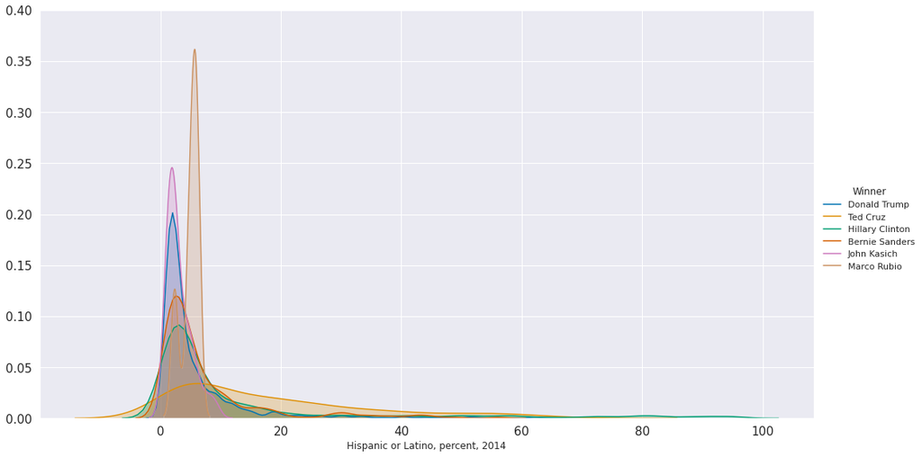

```python
sns.set(font_scale=2.5)
sns.set(rc={'figure.figsize':(15,10)})
fig = sns.FacetGrid(train, hue="Winner", height= 8, aspect=1.8, palette="colorblind")
fig.map(sns.kdeplot,'Hispanic or Latino, percent, 2014',shade= True)
fig.set(ylim=(0, 0.4))
fig.add_legend()
fig.set_yticklabels(size=15)
fig.set_xticklabels(size=15)
plt.show()
```

Let us turn our attention to population related statistics and this time we will use the `factorplot`, which also helps us see the distribution, as well as the average more clearly (the `FaceGrid` does not specify the average).

Firstly, let see the population change (increase or decrease) in county and its correlation with likelihood of candidates winning.

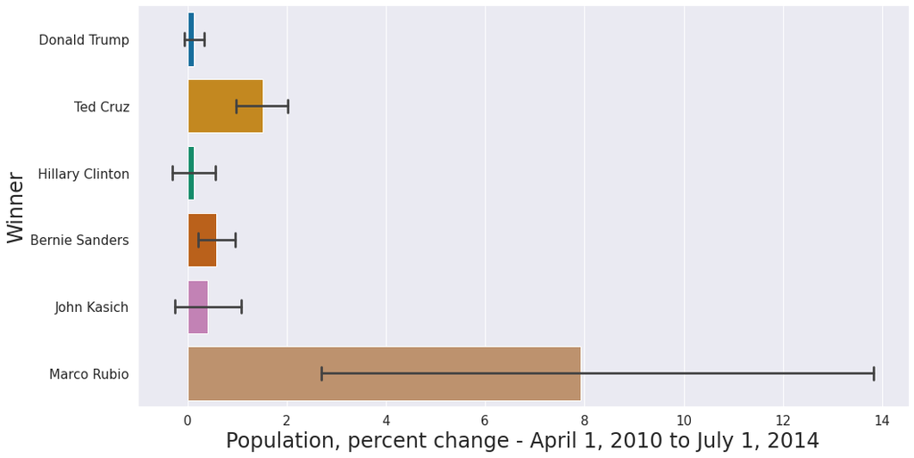

```python
sns.set(font_scale=2)
g = sns.catplot(x = 'Population, percent change - April 1, 2010 to July 1, 2014', y = 'Winner', kind='bar',
                   data=train, height=8, aspect=2, capsize=.2, palette="colorblind")
g.set_yticklabels(size=15)
g.set_xticklabels(size=15)
plt.show()
```

Let us check the poverty levels in the counties where candidates won by plotting `factorplot` with `kind='bar'` for `Persons below poverty level, percent, 2009-2013`.

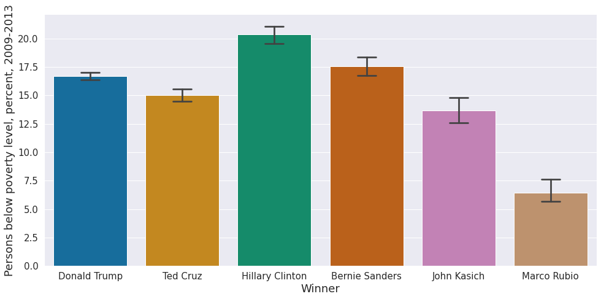

```python
sns.set(font_scale=1.5)
g = sns.catplot(y = 'Persons below poverty level, percent, 2009-2013', x = 'Winner', kind='bar',
                   data=train, height=7, aspect=2, capsize=.2, palette="colorblind")
g.set_yticklabels(size=15)
g.set_xticklabels(size=15)
plt.show()
```

Did Rubio really won such a wealthy counties? A more revealing `factorplot` would be when we set `kind=count`, as done below.

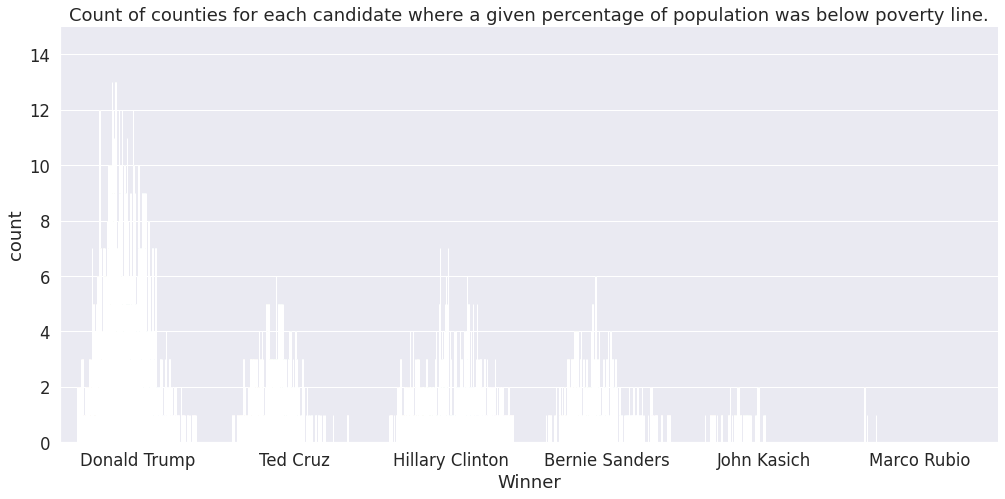

```python
sns.set(font_scale=1.5)
fig = sns.catplot(x="Winner", hue='Persons below poverty level, percent, 2009-2013',
                     data=train, kind='count', height=7, aspect=2, legend=False)
fig.set(ylim=(0, 15))
plt.title('Count of counties for each candidate where a given percentage of population was below poverty line.')
plt.show()
```

Now we will check the distribution of population over 65 in counties where each candidate won.

[figure not shown]

```python
sns.set(font_scale=2.5)
sns.set(rc={'figure.figsize':(15,10)})
fig = sns.FacetGrid(train, hue="Winner", height= 9, aspect=1.5, palette="colorblind")
fig.map(sns.kdeplot,'Persons 65 years and over, percent, 2014',shade= True)
fig.set(ylim=(0, 0.25))
fig.add_legend()
plt.title('Put title here')
fig.set_yticklabels(size=15)
fig.set_xticklabels(size=15)
plt.show()
```

Donald Trump's distribution is the right most, both in terms of its peak and over all distribution range, meaning the counties where he won had slightly higher percentage of older populations.

How about the distribution of population with at least a Bachelor's degree? Let us use the `FacetGrid` to inspect this.

[figure not shown]

```python
sns.set(font_scale=2.5)
sns.set(rc={'figure.figsize':(15,10)})
fig = sns.FacetGrid(train, hue="Winner", height= 9, aspect=1.5, palette="colorblind")
fig.map(sns.kdeplot,"Bachelor's degree or higher, percent of persons age 25+, 2009-2013",shade= True)
fig.set(ylim=(0, 0.1))
fig.add_legend()
plt.title('Put title here')
fig.set_yticklabels(size=15)
fig.set_xticklabels(size=15)
plt.show()
```

Once again we notice that counties when Rubio won have significantly larger proportion of population with Bachelor's degree. However, this does not incorporate the fact the how many counties were won by each candidate? Let us use `kind='count'` in the `factorplot` to see incorporate the information as to how many counties were won by each candidate.

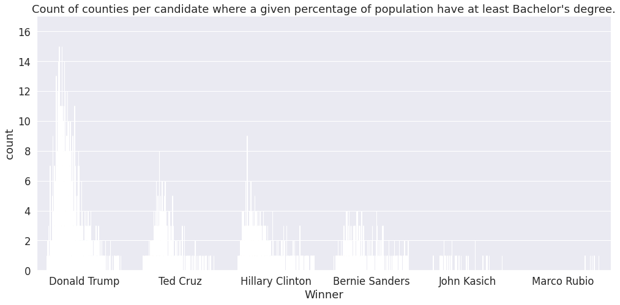

```python
sns.set(font_scale=1.5)
fig = sns.catplot(x="Winner", hue="Bachelor's degree or higher, percent of persons age 25+, 2009-2013",
                     data=train, kind='count', height=7, aspect=2, legend=False)
plt.title('Count of counties per candidate where a given percentage of population have at least Bachelor\'s degree.')
fig.set(ylim=(0, 17))
plt.show()
```

Suddenly the accomplishment of Rubio does not seem to be that huge.

The last distribution that we would like to see is that of `Median household income, 2009-2013` and see which candidate won counties with highest household income.

[figure not shown]

```python
sns.set(font_scale=2.5)
sns.set(rc={'figure.figsize':(15,10)})
fig = sns.FacetGrid(train, hue="Winner", height= 9, aspect=1.5,palette="colorblind")
fig.map(sns.kdeplot,"Median household income, 2009-2013",shade= True)
fig.set(ylim=(0, 0.00007))
fig.add_legend()
plt.title('Put title here')
fig.set_yticklabels(size=15)
fig.set_xticklabels(size=15)
plt.show()
```

Senator Rubio and John Kasich have won counties with with highest household income but once again Rubio won so few counties.

How does the population density affected the chances of a candidate winning? Let us plot `factorplot` with `kind='bar'` and compare the candidates.

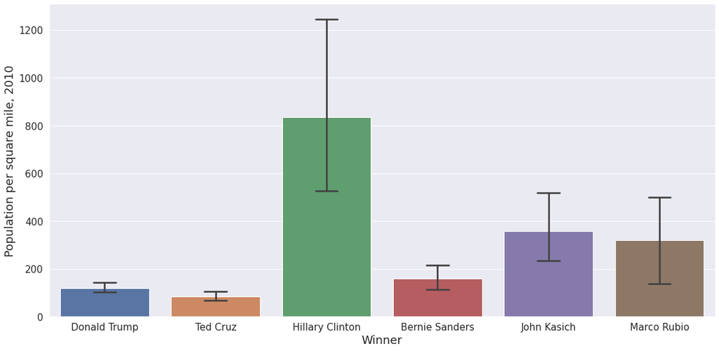

```python
sns.set(font_scale=1.5)
g = sns.catplot(y = 'Population per square mile, 2010', x = 'Winner', kind='bar',
                   data=train, height=8, aspect=2, capsize=0.2)
g.set_yticklabels(size=15)
g.set_xticklabels(size=15)
plt.show()
```

Hillary Clinton won counties where the population density was significantly higher than Trump and most other candidates. The counties won by Donald Trump not only had very small population density, the variation of the distribution was very small too.

#### **4.3 Ranking Candidate Against Average Values of Features**

So far, we have plotted general trends between selected features and each candidate winning. The focus was mostly distribution. It will be very interesting to see the average of feature values in counties (or FIPS code areas) where a candidate won. For example, in the subset of counties where a given candidate won, what is the **average** percentage of population with University degrees? We can plot bar graph for each candidate for each feature.

We write following two functions, where the the second function call the first one. The second function accepts four feature columns and calls the first function to compute average values for each feature and plots it as one of the subplots in 2-by-2 grid. The first function takes input as a feature column name. Inside the function it separates the FIPS areas won by each candidate and then finds average of the passed feature value in the respective counties. (While the approach used in the first function is not optimum in terms of computation resources, as it separates counties won by candidate every time it called but it is optimum in terms of memory resources, as multiple copies of dataframe will not need to be created.)

```python
sns.set()
def average_where_won(feature):

    winner_feat_dict = {}

    for cand in winning_candidates:
        cand_won = train[train['Winner'] == cand]
        winner_feat_dict[cand] = cand_won[feature].mean()


    dict_ave = pd.DataFrame.from_dict(winner_feat_dict, orient = 'index')
    dict_ave.columns = ['Mean value']

    return dict_ave


def quad_plotter(features):

    sns.set(font_scale=1.3)
    plt.figure(figsize=(15,12))
    colors=['red', 'blue', 'green', 'purple', '#624ea7', 'orange']
    for i in range(len(features)):
        average = average_where_won(features[i])
        plt.subplot(2, 2, i + 1)
        plt.bar(list(average.index), average['Mean value'], color=colors)
        plt.xticks(rotation=30)
        plt.gca().set_title(features[i])

    plt.subplots_adjust(hspace=0.4)
    plt.show()
```

##### (a) The Marco-Rubio-Caveat

The several bar graphs below will show some unexpected results for Maco Rubio in terms of FIPS demographics where he won. For example, FIPS areas where he won had the highest percentage of Asian population (even higher than the ones where Clinton won), or highest rate of Bachelor's degree attainment or median income of population and so on. So how do we explain this?

##### (b) Candidates vs population statistics in the counties they won

Firstly, we will be looking into the population counts related features at the counties where each candidate won.

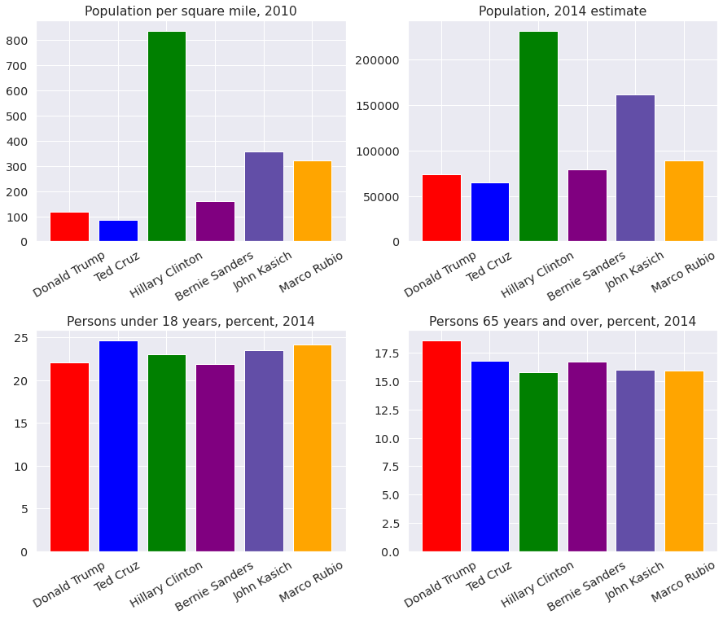

```python
pop_features = ["Population per square mile, 2010",
                "Population, 2014 estimate",
                "Persons under 18 years, percent, 2014",
                "Persons 65 years and over, percent, 2014"]

quad_plotter(pop_features)
```

It can be seen that FIPS areas where Hillary Clinton won, have significantly higher population density compared to other candidates, which means Mrs. Clinton won in dense urban areas. Ted Cruz won where there where percentage of population under 18 was the highest and Donald Trump had slight edge with older populations.

##### (c) Candidates vs racial makeup in the counties they won

Next we inspect the racial make-up of counties where each candidate won. What stands out in the bar graphs below is the support of African Americans for Mrs Clinton. Not surprisingly, Hispanics were more likely to vote for Ted Cruz than any other candidate. And surprisingly, counties where Senator Sanders won had the lowest proportion of African Americans.

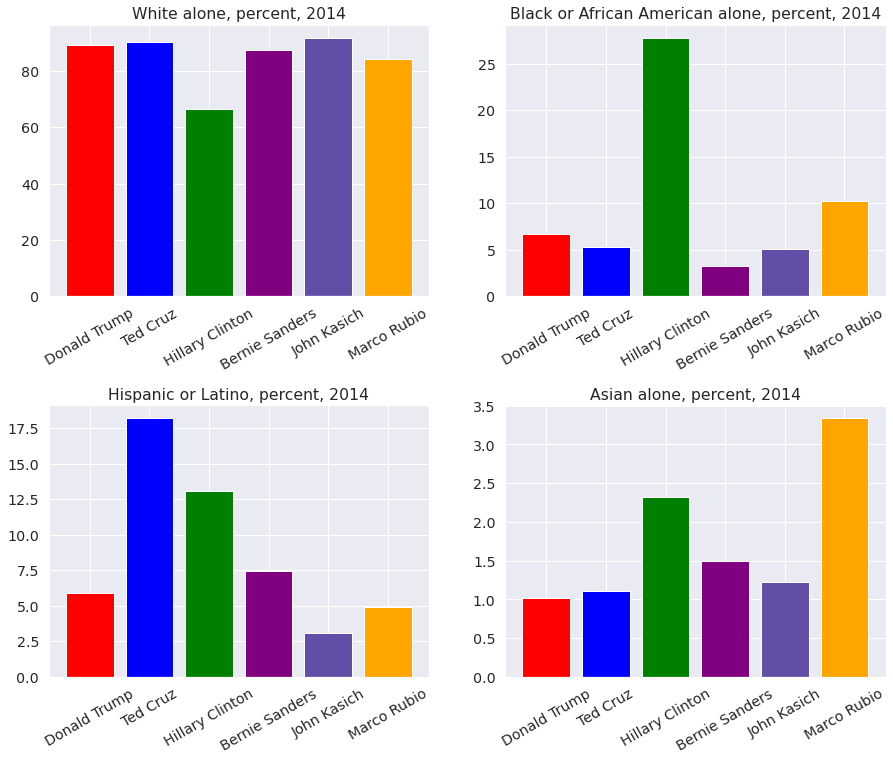

```python
race_features = ["White alone, percent, 2014",
                "Black or African American alone, percent, 2014",
                "Hispanic or Latino, percent, 2014",
                "Asian alone, percent, 2014"]

quad_plotter(race_features)
```

##### (d) Candidates against socio-economic status in the counties they won

Hillary Clinton was supported by highest proportion of population living under poverty line. The graph at bottom right indicates that, while most metrics of income reveal Republican voters to be wealthy, not counting the Marco Rubio's wins in 7 FIPS areas, Democrat voters lived in slightly more expensive housing units.

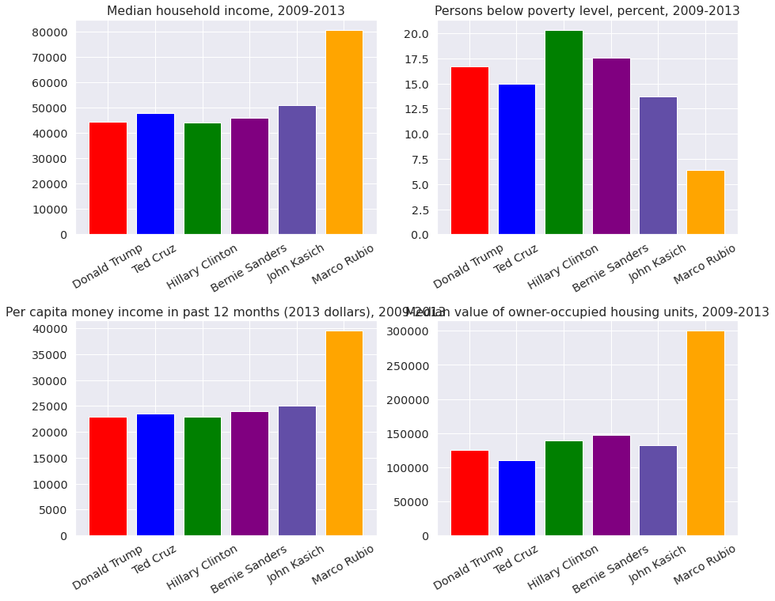

```python
income_features = ["Median household income, 2009-2013",
                "Persons below poverty level, percent, 2009-2013",
                "Per capita money income in past 12 months (2013 dollars), 2009-2013",
                "Median value of owner-occupied housing units, 2009-2013"]

quad_plotter(income_features)
```

##### (e) Candidates vs gender, education & place of birth statistics in the counties they won

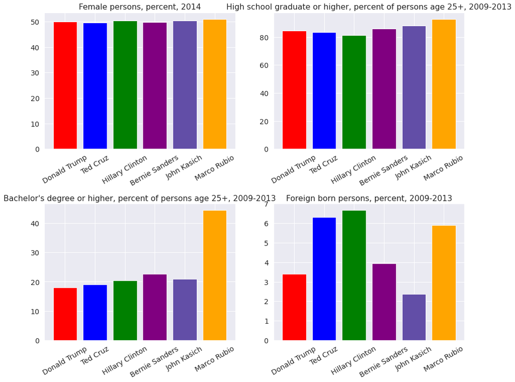

```python
misc_features = ["Female persons, percent, 2014",
                "High school graduate or higher, percent of persons age 25+, 2009-2013",
                "Bachelor's degree or higher, percent of persons age 25+, 2009-2013",
                "Foreign born persons, percent, 2009-2013"]

quad_plotter(misc_features)
```

#### **4.4 Correlation between Demographic Features and the Winning Candidate**

While bar plots allowed us distribution of feature values where a candidate won, the shortcoming of this approach is that we did not test all features, as there are too many. We can compute correlations to deduce more specific information as which factors made a candidate win across call the counties. Since our label is categorical, we will convert it into dummies variable for winning candidates, which will be inserted into our new temporary dataframe, `dataCorrelations`, for correlations.

```python
dummiesForWinners = pd.get_dummies(train['Winner'])
dataCorrelations = pd.concat([train, dummiesForWinners], axis=1)
```

We will not use some independent variables in correlations; these include `FIPS` code for obvious reasons and `County` because it has high cardinality and one-hot encoding on it will complicate things. We drop these features in the following, along with `Winner` as corresponding dummies have been inserted already.

```python
dataCorrelations.drop(['FIPS','County','Winner'], axis=1, inplace=True)
```

Now we compute the correlation matrix:

```python
corr_mat = dataCorrelations.corr()
```

Next we compute correlation of feature for each candidate in descending order because we are interested in top-five factor for each candidate:

```python
Trump   = corr_mat["Donald Trump"   ].sort_values(ascending=False)
Clinton = corr_mat["Hillary Clinton"].sort_values(ascending=False)
Sanders = corr_mat["Bernie Sanders" ].sort_values(ascending=False)
Kasich  = corr_mat["John Kasich"    ].sort_values(ascending=False)
Rubio   = corr_mat["Marco Rubio"    ].sort_values(ascending=False)
Cruz    = corr_mat["Ted Cruz"       ].sort_values(ascending=False)
```

And it is time to see the results.

###### A. Donald Trump:

Following are the top-five most important factors which made Donald Trump more likely to get votes. In other words, in the counties with plenty of these five factors, Trump was more likely to win.

```python
DT = pd.DataFrame(Trump[1:6])
DT.columns = ['Correlation with Trump winning']
printDF(DT)
```

|  | Correlation with Trump winning |
| --- | --- |
| White alone, not Hispanic or Latino, percent, 2014 | 0.381639 |
| White alone, percent, 2014 | 0.273433 |
| Persons 65 years and over, percent, 2014 | 0.256721 |
| Homeownership rate, 2009-2013 | 0.191520 |
| Living in same house 1 year & over, percent, 2009-2013 | 0.139967 |

###### B. Hillary Clinton:

Similarly, following are the top-5 for Mrs. Clinton. It is interesting that correlation between African Americans and Clinton is much stronger than correlation between White Americans and Mr Trump. Again, poverty seems to be correlated with votes for Mrs. Clinton.

```python
HC = pd.DataFrame(Clinton[1:6])
HC.columns = ['Correlation with Clinton winning']
printDF(HC)
```

|  | Correlation with Clinton winning |
| --- | --- |
| Black or African American alone, percent, 2014 | 0.580260 |
| Black-owned firms, percent, 2007 | 0.459285 |
| Asian-owned firms, percent, 2007 | 0.247466 |
| Persons below poverty level, percent, 2009-2013 | 0.243121 |
| Hispanic-owned firms, percent, 2007 | 0.229857 |

###### C. Bernie Sanders

The top factors for Bernie Sanders include being of mixed race and having a Bachelor's degree and interestingly the native Americans.

```python
BS = pd.DataFrame(Sanders[1:6])
BS.columns = ['Correlation with Sanders winning']
printDF(BS)
```

|  | Correlation with Sanders winning |
| --- | --- |
| Two or More Races, percent, 2014 | 0.239710 |
| American Indian and Alaska Native alone, percent, 2014 | 0.177938 |
| American Indian- and Alaska Native-owned firms, percent, 2007 | 0.171529 |
| Bachelor's degree or higher, percent of persons age 25+, 2009-2013 | 0.145577 |
| High school graduate or higher, percent of persons age 25+, 2009-2013 | 0.120251 |

###### D. John Kasich

```python
JK = pd.DataFrame(Kasich[1:6])
JK.columns = ['Correlation with Kasich winning']
printDF(JK)
```

|  | Correlation with Kasich winning |
| --- | --- |
| White alone, not Hispanic or Latino, percent, 2014 | 0.089063 |
| High school graduate or higher, percent of persons age 25+, 2009-2013 | 0.085853 |
| Median household income, 2009-2013 | 0.066590 |
| White alone, percent, 2014 | 0.061302 |
| Housing units in multi-unit structures, percent, 2009-2013 | 0.059370 |

###### E. Ted Cruz

Ted Cruz was popular in counties with higher under-18 and under-5 populations, and Hispanics populations.

```python
TC = pd.DataFrame(Cruz[1:6])
TC.columns = ['Correlation with Cruz winning']
printDF(TC)
```

|  | Correlation with Cruz winning |
| --- | --- |
| Hispanic or Latino, percent, 2014 | 0.269397 |
| Persons under 18 years, percent, 2014 | 0.252187 |
| Language other than English spoken at home, pct age 5+, 2009-2013 | 0.193021 |
| Persons per household, 2009-2013 | 0.176161 |
| Persons under 5 years, percent, 2014 | 0.174361 |

###### F. Marco Rubio

I would like to repeat the *caveat* with Senator Rubio because he won only 7 FIPS area codes, which is not enough to generalise that these are his typical voters but in the 7 FIPS he won, he was popular amongst University educated and wealthy populations. It can be seen that most features have rather *low correlations* with Rubio winning.

```python
MR = pd.DataFrame(Rubio[1:6])
MR.columns = ['Correlation with Rubio winning']
printDF(MR)
```

|  | Correlation with Rubio winning |
| --- | --- |
| Median household income, 2009-2013 | 0.142753 |
| Per capita money income in past 12 months (2013 dollars), 2009-2013 | 0.140373 |
| Bachelor's degree or higher, percent of persons age 25+, 2009-2013 | 0.133906 |
| Median value of owner-occupied housing units, 2009-2013 | 0.107205 |
| Population, percent change - April 1, 2010 to July 1, 2014 | 0.090340 |

#### **4.5 Taking Care of Class Imbalance**

And finally, we will take care of class-imbalance:

```python
from sklearn.utils import resample
import numpy as np

def LabelImbalanceRemover(data):

    majority_class   = data['Winner'].value_counts().index[0]
    minority_classes = list(set(np.unique(data['Winner'])) - set([majority_class]))

    data_temp = data[data['Winner'] == majority_class]
    majority_count = len(data_temp)
    print(majority_count)

    for label in minority_classes:
        current_class = data[data['Winner'] == label]
        temp = resample(current_class, replace=True, n_samples=int(majority_count*0.75), random_state=63)
        data_temp = pd.concat([data_temp, temp])

    data_temp.reset_index(drop=True, inplace=True)

    return data_temp

#train = LabelImbalanceRemover(train)

print_class_dist(train["Winner"])
```

```
                 Counts  Winner
Donald Trump       1103  49.48%
Hillary Clinton     448   20.1%
Ted Cruz            342  15.34%
Bernie Sanders      289  12.97%
John Kasich          42   1.88%
Marco Rubio           5   0.22%
```

And let us also separate the features from the label:

```python
X_train = train.drop('Winner', axis = 1)
y_train = pd.DataFrame(train['Winner'], columns=['Winner'])
```

### **5. Pipelines to Clean & Preprocess Data and Engineer New Features**

Since the preprocessing and cleaning of data depends on the nature of the variable (column), the first section of pipe is split data into categorical and numerical variables. But we need to determine the list of columns in each.

```python
obviously_cat = list(X_train.loc[:,X_train.dtypes==np.object])

print("Obviously categorical columns: ", obviously_cat)
```

```
Obviously categorical columns:  ['County', 'State']
```

There are two non-numeric columns, which are obviously categorical. However, we will not use use the `County` in the model due to it being a categorical column with large number of unique values. Also, the `FIPS`, numerical columns is a *unique* identification column, it will not be processed as well. With this information at our hands, let us create the list of categoricl and numerical columns:

```python
categorical_columns = list(set(list(X_train.loc[:,X_train.dtypes==np.object])) - set(['County']))

numerical_columns   = list(set(set(list(X_train.columns)) - set(categorical_columns + ['County', 'FIPS'])))
```

We also need to check if any **columns have negative values**:

```python
temp = pd.DataFrame(X_train[numerical_columns].min(), columns=['Minimum value'])
temp[temp.values < 0]
```

|  | Minimum value |
| --- | --- |
| Private nonfarm employment, percent change, 2012-2013 | -71.5 |
| Population, percent change - April 1, 2010 to July 1, 2014 | -13.4 |

So we have two columns with negative values. Let us store them in a list to take care of them when processing numerical columns:

```python
cols_with_negative_values = list(temp[temp.values < 0].index)
```

#### **5.1 Bifurcation: Categorical and Non-categorical Subbranches of the Pipe**

The following class, `FeatureSelector` will take the list of columns and return those columns. In our case, we will use this class to extract the numerical and categorical columns.

```python
import numpy as np
from sklearn.base import BaseEstimator, TransformerMixin

class FeatureSelector(BaseEstimator, TransformerMixin):
    """
    The first section of pipeline extracts the the columns from dataset when list of columns is provided as argument.
    This will be used to extract either the numeric and categorical columns from total dataset, to process them individually.
    """
    def __init__(self, feature_names):
        self._feature_names = feature_names

    #Return self nothing else to do here
    def fit(self, X, y = None):
        return self

    #Method that describes what we need this transformer to do
    def transform(self, X, y = None):
        return X[self._feature_names]
```

#### **5.2 Handling Missing Values: `DataFrameImputer` will be used for both numerical and categorical columns**

The `SimpleImputer` built into the `sklearn` library support many strategies for handling missing value, with `strategy='mean` for numerical data and `strategy='most_frequent` for categorical. However, the implementation of `strategy='most_frequent` tends to be very slow, so we could use a trick wherein we pass `strategy='common` as strategy for categorical features and supply the most frequent entries of each column through the `fill_values` argument. However, since we have only one categorical column in this dataset, we will allow `strategy='most_frequent` without significant performance slow-down.

```python
from sklearn.impute import SimpleImputer

class DataFrameImputer(BaseEstimator, TransformerMixin):

    """
    Just a wrapper for the SimpleImputer that keeps the dataframe structure
    """

    def __init__(self, strategy='mean'):
        self.strategy = strategy
        self.imp = None
        self.statistics_ = None

    def fit(self, X, y=None):
        self.imp = SimpleImputer(strategy=self.strategy)
        self.imp.fit(X)
        self.statistics_ = pd.Series(self.imp.statistics_, index=X.columns)
        return self

    def transform(self, X):
        # X is supposed to be a DataFrame
        Ximp = self.imp.transform(X)
        Xfilled = pd.DataFrame(Ximp, index=X.index, columns=X.columns)
        return Xfilled
```

#### **5.2. Processing Categorical Pipeline**

##### **5.2.1. Categorical Feature Engineering: ```Region``` and ```Date of Primary```** :

**```Region```**: Populations in various parts of US vote differently. While State of the particular FIPS code (county) will incorporate information about the region indireclty, making a separate feature will provide additional information for machine learning algorithm with which to work. The *United States Census Bureau* divides the nation into nine geographical regions, each comprising of several states. We will use these in this project.

**```Date of Primary```**: As mentioned in the introduction, in US presidential primaries, especially in the Republican primaries, candidates tend to drop out as the race progresses, so that only a few candidates remain by the end of primaries. This would obivously affect which candidate will win, since some candidates are not running and algorithms should be trained with this information. Since none of our independent variables reveal such information, we extract it from external sources; in particular, Wikipedia prodives these dates for [Democrates](https://en.m.wikipedia.org/wiki/Democratic_Party_presidential_primaries,_2016) and [Republicans](https://en.m.wikipedia.org/wiki/Republican_Party_presidential_primaries,_2016) primaries. We will create a new column `Date of Primaries`, based upon when the primaries were held in the states, we assigned them a number; bigger the number, latter they had primaries.

The second problem that arises here is that in a few States, certainly not a majority of them, the Republican and Democratic parities had their primaries on different dates. Since Democratic candidates rarely drop out in the race and since there are few states where two parties have primaries on different dates, to keep things simple, we will just Republican primaries as date of primaries for states. This will introduce some minor inaccuracies for states but it will capture the trend well.

In the following cell, we create a class to create `Region` feature based upon these 9 geographical regions as well as use Wikipedia information to get presidential primaries dates for each state, create the dictionary with state and date paired up in it, and then engineer new feature `Date of Primaries`:

```python
class CatFeatureEngineer(BaseEstimator, TransformerMixin):

    """
    In this section of pipeline, we will engineer two feature:
    -- 'Region'            : This will be engineered from feature 'State'
    -- 'Date of Primaries' : This will be engineered from data extracted from Wikipedia
    """

    def fit(self, X, y=None):
        return self

    def region_creator(self, State):

        New_England        = ["Maine", "New Hampshire", "Vermont", "Massachusetts", "Rhode Island", "Connecticut"]
        Middle_Atlantic    = ["New York", "Pennsylvania", "New Jersey"]
        East_North_Central = ["Wisconsin", "Michigan", "Illinois", "Indiana", "Ohio"]
        West_North_Central = ["North Dakota", "South Dakota", "Nebraska", "Kansas", "Minnesota", "Iowa", "Missouri"]
        South_Atlantic     = ["Delaware", "Maryland", "DC", "Virginia", "West Virginia", "North Carolina", "South Carolina", "Georgia", "Florida"]
        East_South_Central = ["Kentucky", "Tennessee", "Mississippi", "Alabama"]
        West_South_Central = ["Oklahoma", "Texas", "Arkansas", "Louisiana"]
        Mountain           = ["Idaho", "Montana", "Wyoming", "Nevada", "Utah", "Colorado", "Arizona", "New Mexico"]
        Pacific             = ["Alaska", "Washington", "Oregon", "California", "Hawaii"]

        if State in New_England:
            return "New England"
        elif State in Middle_Atlantic:
            return "Middle Atlantic"
        elif State in East_North_Central:
            return "East North Central"
        elif State in West_North_Central:
            return "West North Central"
        elif State in South_Atlantic:
            return "South Atlantic"
        elif State in East_South_Central:
            return "East South Central"
        elif State in West_South_Central:
            return "West South Central"
        elif State in Mountain:
            return "Mountain"
        elif State in Pacific:
            return "Pacific"
        else:
            return "Notfound"


    def transform(self, X, y=None):

        X["Region"] = X["State"].apply(self.region_creator)

        dictRepub = {"Iowa" : "February 1", "New Hampshire" : "February 9", "South Carolina" : "February 20",
                     "Nevada" : "February 23", "Alabama" : "March 1", "Alaska"  : "March 5", "Arkansas" : "March 5",
                     "Colorado" : "March 5", "Georgia" : "March 5", "Massachusetts" : "March 5", "Minnesota" : "March 5",
                     "North Dakota" : "March 5", "Oklahoma" : "March 5", "Tennessee" : "March 5", "Texas" : "March 5",
                     "Vermont" : "March 5", "Virginia" : "March 5", "Wyoming" : "March 5", "Kansas" : "March 5",
                     "Kentucky" : "March 5", "Louisiana" : "March 5", "Maine" : "March 5", "Hawaii" : "March 8",
                     "Idaho" : "March 8", "Michigan" : "March 8", "Mississippi" : "March 8", "Florida" : "March 15",
                     "Illinois" : "March 15", "Missouri" : "March 15", "North Carolina" : "March 15", "Ohio" : "March 15",
                     "Arizona" : "March 22", "Utah" : "March 22", "Wisconsin" : "April 5", "New York" : "April 19",
                     "Connecticut" : "April 26", "Delaware" : "April 26", "Maryland" : "April 26", "Pennsylvania" : "April 26",
                     "Rhode Island" : "April 26", "Indiana" : "May 3", "Nebraska" : "May 10", "West Virginia" : "May 10",
                     "Oregon" : "May 17", "Washington" : "May 24", "California" : "June 7", "Montana" : "June 7",
                     "New Jersey" : "June 7", "New Mexico" : "June 7", "South Dakota" : "June 7"}

        X["Date of Primaries"] = X["State"].apply(lambda x: dictRepub[x])

        return X
```

##### **5.2.4. Categorical Columns: One-Hot Encoding**

The dummy encoding is required since some machine learning algorithms cannot work with non-numeric variables. In the following we create a class to carry out dummay encoding.

```python
class dummify(BaseEstimator, TransformerMixin):

    """
    Wrapper for get dummies
    """

    def __init__(self, drop_first=False, match_cols=True):
        self.drop_first = drop_first
        self.columns = []  # useful to well behave with FeatureUnion
        self.match_cols = match_cols

    def fit(self, X, y=None):
        self.columns = []  # for safety, when we refit we want new columns
        return self

    def match_columns(self, X):
        miss_train = list(set(X.columns) - set(self.columns))
        miss_test = list(set(self.columns) - set(X.columns))

        err = 0

        if len(miss_test) > 0:
            for col in miss_test:
                X[col] = 0  # insert a column for the missing dummy
                err += 1
        if len(miss_train) > 0:
            for col in miss_train:
                del X[col]  # delete the column of the extra dummy
                err += 1

        X = X[self.columns]
        return X

    def transform(self, X):
        X = pd.get_dummies(X, drop_first=self.drop_first)
        if (len(self.columns) > 0):
            if self.match_cols:
                X = self.match_columns(X)
            self.columns = X.columns
        else:
            self.columns = X.columns
        return X

    def get_features_name(self):
        return self.columns
```

#### **5.3. Processing Numerical Pipeline**

```python
class SkewRemover(BaseEstimator, TransformerMixin):
    """
    ABC
    """

    def __init__(self, cols_with_negative_values):
        self.columns = []  # useful to well behave with FeatureUnion
        self.cols_with_negative_values = cols_with_negative_values


    def fit(self, X, y=None):
        return self

    def adjust_negative(self, X, column):
        X[column] = X[column] + (-1*(np.min(X[column] - 1)))
        return X

    def remove_skew(self, X, column):
        X[column] = np.log1p(X[column])
        return X

    def transform(self, X, y=None):
        for col in X.columns:
            if col in self.cols_with_negative_values:
                X = self.adjust_negative(X, col)

            X = self.remove_skew(X, col)

        self.columns = X.columns
        return X

    def get_features_name(self):
        return self.columns
```

#### **5.4. Union of Numerical and Categorical Columns**

```python
from sklearn.pipeline import FeatureUnion

class FeatureUnion_df(TransformerMixin, BaseEstimator):
    '''
    Wrapper of FeatureUnion but returning a Dataframe,
    the column order follows the concatenation done by FeatureUnion

    transformer_list: list of Pipelines

    '''
    def __init__(self, transformer_list, n_jobs=None, transformer_weights=None, verbose=False):
        self.transformer_list = transformer_list
        self.n_jobs = n_jobs
        self.transformer_weights = transformer_weights
        self.verbose = verbose  # these are necessary to work inside of GridSearch or similar
        self.feat_un = FeatureUnion(self.transformer_list,
                                    self.n_jobs,
                                    self.transformer_weights,
                                    self.verbose)

    def fit(self, X, y=None):
        self.feat_un.fit(X)
        return self

    def transform(self, X, y=None):

        X_tr = self.feat_un.transform(X)
        columns = []

        for trsnf in self.transformer_list:
            cols = trsnf[1].steps[-1][1].get_features_name()  # getting the features name from the last step of each pipeline
            columns += list(cols)

        X_tr = pd.DataFrame(X_tr, index=X.index, columns=columns)

        return X_tr

    def get_params(self, deep=True):  # necessary to well behave in GridSearch
        return self.feat_un.get_params(deep=deep)
```

#### **5.5. Standardisation of the Features**

```python
from sklearn.preprocessing import StandardScaler, RobustScaler

class StandardiseDF(BaseEstimator, TransformerMixin):
    '''
    Wrapper of StandardScaler or RobustScaler
    '''
    def __init__(self, method='standard'):
        self.scl = None
        self.scale_ = None
        self.method = method
        if self.method == 'sdandard':
            self.mean_ = None
        elif method == 'robust':
            self.center_ = None
        self.columns = None  # this is useful when it is the last step of a pipeline before the model

    def fit(self, X, y=None):
        if self.method == 'standard':
            self.scl = StandardScaler()
            self.scl.fit(X)
            self.mean_ = pd.Series(self.scl.mean_, index=X.columns)
        elif self.method == 'robust':
            self.scl = RobustScaler()
            self.scl.fit(X)
            self.center_ = pd.Series(self.scl.center_, index=X.columns)
        self.scale_ = pd.Series(self.scl.scale_, index=X.columns)
        return self

    def transform(self, X):
        # assumes X is a DataFrame
        Xscl = self.scl.transform(X)
        Xscaled = pd.DataFrame(Xscl, index=X.index, columns=X.columns)
        self.columns = X.columns
        return Xscaled

    def get_feature_names(self):
        return list(self.columns)  # this is going to be useful when coupled with FeatureUnion
```

#### **5.5. Dimentionality Reduction**

```python
from sklearn.decomposition import PCA

class CustomPCA(BaseEstimator, TransformerMixin):
    '''
    Wrapper of StandardScaler or RobustScaler
    '''
    def __init__(self, preserve_variance=0.95):
        self.preserve_variance = preserve_variance


    def fit(self, X, y=None):
        self.pipe_pca = PCA(self.preserve_variance)
        self.pipe_pca.fit(X)
        return self

    def transform(self, X):
        X_tr = self.pipe_pca.transform(X)
        cols = ['principal component number ' + str(num) for num in range(1, X_tr.shape[1] + 1)]
        X_tr = pd.DataFrame(X_tr, columns=cols)
        return X_tr
```

#### **5.6. Building Full Pipes**

```python
from sklearn.pipeline import Pipeline

numeric_pipe = Pipeline([('num_features',     FeatureSelector(numerical_columns)),
                         ('imputer',          DataFrameImputer(strategy='median')),
                         ('remove_skew',      SkewRemover(cols_with_negative_values))])


cat_pipe     = Pipeline([('num_features',     FeatureSelector(categorical_columns)),
                         ('imputer',          DataFrameImputer(strategy='most_frequent')),
                         ('feature_engineer', CatFeatureEngineer()),
                         ('dummies',          dummify())])


processing_pipe = FeatureUnion_df(transformer_list=[('num_pipe', numeric_pipe),
                                                    ('cat_pipe', cat_pipe)])


temp_pipe = Pipeline([('processing',  processing_pipe),
                      ('scl',         StandardiseDF()),
                      ('pca',         CustomPCA(preserve_variance=0.95))])
```

And finally, we pass our train and test datasets: the train set will use `fit_transform()` method, whereas the test set will use `transform()` method.

```python
X_train = temp_pipe.fit_transform(X_train)
X_test  = temp_pipe.transform(X_test)
```

```python
import warnings
from sklearn.exceptions import ConvergenceWarning

warnings.filterwarnings("ignore", category=RuntimeWarning)
warnings.filterwarnings(action='ignore', category=ConvergenceWarning)

warnings.filterwarnings("ignore", category=RuntimeWarning)
warnings.filterwarnings(action='ignore', category=ConvergenceWarning)
warnings.filterwarnings("ignore", category=DeprecationWarning)
```

```python
from sklearn.preprocessing import label_binarize
n_classes = len(np.unique(y_train))

y_train_bin = label_binarize(y_train, classes=list(np.unique(y_train)))
y_test_bin  = label_binarize(y_test, classes=list(np.unique(y_test)))
```

```python
from sklearn.metrics import roc_curve, auc
from sklearn.preprocessing import label_binarize
from scipy import interp
from itertools import cycle


def custom_roc_auc(y_test_bin, y_score, n_classes):

    fpr, tpr, roc_auc = dict(), dict(), dict()

    for i in range(n_classes):
        fpr[i], tpr[i], _ = roc_curve(y_test_bin[:, i], y_score[:, i])

        roc_auc[i] = auc(fpr[i], tpr[i])

    fpr["micro"], tpr["micro"], _ = roc_curve(y_test_bin.ravel(), y_score.ravel())
    roc_auc["micro"] = auc(fpr["micro"], tpr["micro"])

    all_fpr = np.unique(np.concatenate([fpr[i] for i in range(n_classes)]))

    mean_tpr = np.zeros_like(all_fpr)

    for i in range(n_classes):
        mean_tpr += interp(all_fpr, fpr[i], tpr[i])

    mean_tpr /= n_classes

    fpr["macro"] = all_fpr
    tpr["macro"] = mean_tpr
    roc_auc["macro"] = auc(fpr["macro"], tpr["macro"])

    return roc_auc['macro']
```

### **6. Building Model**

```python
from sklearn.svm import SVC
from sklearn.model_selection import RandomizedSearchCV
from sklearn.metrics import accuracy_score, recall_score, f1_score, roc_auc_score, make_scorer, precision_score

my_scorer = make_scorer(f1_score, greater_is_better=True, average='weighted')

param_search = {"C"            : [float(2**x) for x in np.linspace(start=-4,  stop=4,  num= 9)],
                "tol"          : [float(2**x) for x in np.linspace(start=-6,  stop=1,  num= 8)],
                "gamma"        : [float(2**x) for x in np.linspace(start=-10, stop=10, num= 8)],
                "degree"       : [int(x)      for x in np.linspace(start=2,   stop=10, num= 5)],
                "kernel"       : ['linear'],
                "class_weight" : ['balanced', None],
                "shrinking"    : [True, False],
                "random_state" : [42]}

SVC_est = SVC(probability=True)

random_search = RandomizedSearchCV(estimator = SVC_est,
                                   param_distributions = param_search,
                                   n_iter = 200,
                                   cv = 5,
                                   random_state=42,
                                   n_jobs = -1,
                                   scoring=my_scorer)

random_search.fit(X_train, np.ravel(y_train))

SVCtuned = random_search.best_estimator_

y_pred_train = SVCtuned.predict(X_train)
y_pred_test = SVCtuned.predict(X_test)

print("Train accuracy : {0:.2%}".format(accuracy_score(y_train, y_pred_train)))
print("Test  accuracy : {0:.2%}".format(accuracy_score(y_test, y_pred_test)))

y_pred_train_proba = SVCtuned.predict_proba(X_train)
y_pred_test_proba  = SVCtuned.predict_proba(X_test)

train_roc_auc = custom_roc_auc(y_train_bin, y_pred_train_proba, n_classes)
test_roc_auc  = custom_roc_auc(y_test_bin, y_pred_test_proba, n_classes)

print("\nTrain ROC-AUC     : {0:.4f}".format(train_roc_auc))
print("Test ROC-AUC      : {0:.4f}".format(test_roc_auc ))
```

```
Train accuracy : 82.59%
Test  accuracy : 70.97%

Train ROC-AUC     : 0.9704
Test ROC-AUC      : 0.9007
```

```python
from sklearn.model_selection import RandomizedSearchCV
from sklearn.ensemble import RandomForestClassifier

my_scorer = make_scorer(f1_score, greater_is_better=True, average='weighted')

param_search = {"max_depth"         : [int(x) for x in np.linspace(start = 2,   stop=20,   num=10)],
                "max_leaf_nodes"    : [int(x) for x in np.linspace(start = 2,   stop=20,   num=10)],
                "min_samples_leaf"  : [int(x) for x in np.linspace(start = 2,   stop=10,   num=10)],
                "min_samples_split" : [int(x) for x in np.linspace(start = 2,   stop=10,   num=10)],
                "n_estimators"      : [int(x) for x in np.linspace(start = 100, stop=1500, num=100)],
                "max_features"      : ['auto', 'sqrt', 'log2', None],
                "random_state"      : [42]}

randForest = RandomForestClassifier()

random_search = RandomizedSearchCV(estimator = randForest,
                                   param_distributions = param_search,
                                   n_iter = 200,
                                   cv = 5,
                                   random_state=42,
                                   n_jobs=-1,
                                   scoring=my_scorer)

random_search.fit(X_train, np.ravel(y_train))

forestTuned = random_search.best_estimator_

y_pred_train = forestTuned.predict(X_train)
y_pred_test = forestTuned.predict(X_test)

print("Train accuracy : {0:.2%}".format(accuracy_score(y_train, y_pred_train)))
print("Test  accuracy : {0:.2%}".format(accuracy_score(y_test, y_pred_test)))

y_pred_train_proba = forestTuned.predict_proba(X_train)
y_pred_test_proba  = forestTuned.predict_proba(X_test)

train_roc_auc = custom_roc_auc(y_train_bin, y_pred_train_proba, n_classes)
test_roc_auc  = custom_roc_auc(y_test_bin, y_pred_test_proba, n_classes)

print("\nTrain ROC-AUC     : {0:.4f}".format(train_roc_auc))
print("Test ROC-AUC      : {0:.4f}".format(test_roc_auc ))
```

```
Train accuracy : 75.95%
Test  accuracy : 70.07%

Train ROC-AUC     : 0.9518
Test ROC-AUC      : 0.8468
```

```python
from sklearn.neural_network import MLPClassifier
from sklearn.model_selection import RandomizedSearchCV

from sklearn.metrics import accuracy_score, recall_score, f1_score, roc_auc_score, make_scorer, precision_score

my_scorer = make_scorer(f1_score, greater_is_better=True, average='weighted')

param_space = {'tol'                          :  [float(x) for x in np.linspace(start=0.00001, stop=0.99999, num = 100)],
               'alpha'                        :  [float(x) for x in np.linspace(start=0.00001, stop=0.99999, num = 100)],
               'beta_1'                       :  [float(x) for x in np.linspace(start=0.00001, stop=0.99999, num = 100)],
               'beta_2'                       :  [float(x) for x in np.linspace(start=0.00001, stop=0.99999, num = 100)],
               'learning_rate_init'           :  [float(x) for x in np.linspace(start=0.00001, stop=0.99999, num = 100)],
               'max_iter'                     :  [int(x)   for x in np.linspace(start= 100,    stop=800,     num = 100)],
               'batch_size'                   :  [30, 60, 90, 120, 150, 180, 210, 'auto'],
               'learning_rate'                :  ['constant', 'invscaling', 'adaptive'],
               'solver'                       :  ['adam', 'lbfgs', 'sgd'],
               'early_stopping'               :  [True, False],
               'activation'                   :  ['identity', 'logistic', 'tanh', 'relu'],
               'hidden_layer_sizes'           :  [(50, 50, 50), (75, 75, 75), (100, 100, 100), (125, 125, 125)]}

MLPCclf = MLPClassifier()
random_search = RandomizedSearchCV(estimator = MLPCclf,
                                   param_distributions = param_space,
                                   n_iter = 200,
                                   cv = 5,
                                   random_state=42,
                                   n_jobs=-1,
                                   scoring=my_scorer)

random_search.fit(X_train, np.ravel(y_train))
MLPC_tuned = random_search.best_estimator_

y_pred_train = MLPC_tuned.predict(X_train)
y_pred_test = MLPC_tuned.predict(X_test)

print("Train accuracy : {0:.2%}".format(accuracy_score(y_train, y_pred_train)))
print("Test  accuracy : {0:.2%}".format(accuracy_score(y_test, y_pred_test)))

y_pred_train_proba = MLPC_tuned.predict_proba(X_train)
y_pred_test_proba  = MLPC_tuned.predict_proba(X_test)

train_roc_auc = custom_roc_auc(y_train_bin, y_pred_train_proba, n_classes)
test_roc_auc  = custom_roc_auc(y_test_bin, y_pred_test_proba, n_classes)

print("\nTrain ROC-AUC     : {0:.4f}".format(train_roc_auc))
print("Test ROC-AUC      : {0:.4f}".format(test_roc_auc ))
```

```
Train accuracy : 93.05%
Test  accuracy : 70.97%

Train ROC-AUC     : 0.9903
Test ROC-AUC      : 0.8753
```

```python
from xgboost import XGBClassifier
from sklearn.model_selection import RandomizedSearchCV

from sklearn.metrics import accuracy_score, recall_score, f1_score, roc_auc_score, make_scorer, precision_score

my_scorer = make_scorer(f1_score, greater_is_better=True, average='weighted')

param_search = {"reg_alpha"        : [float(x) for x in np.linspace(start=0,      stop=20,   num = 50)],
                "reg_lambda"       : [float(x) for x in np.linspace(start=0,      stop=20,   num = 50)],
                "learning_rate"    : [float(x) for x in np.linspace(start=0,      stop=5,    num = 10)],
                "subsample"        : [float(x) for x in np.linspace(start=0,      stop=1,    num = 10)],
                "gamma"            : [float(x) for x in np.linspace(start=0,      stop=20,   num = 20)],
                "eta"              : [float(x) for x in np.linspace(start=0,      stop=20,   num = 20)],
                "colsample_bytree" : [float(x) for x in np.linspace(start=0,      stop=1,    num = 50)],
                "base_score"       : [float(x) for x in np.linspace(start=0.01,   stop=0.9,  num = 10)],

                "n_estimators"     : [int(x)   for x in np.linspace(start=1,      stop=500,  num = 50)],
                "max_depth"        : [int(x)   for x in np.linspace(start=1,      stop=30,   num = 30)],
                "max_delta_step"   : [int(x)   for x in np.linspace(start=1,      stop=30,   num = 30)],
                "min_child_weight" : [int(x)   for x in np.linspace(start=1,      stop=30,   num = 30)],

                "booster"          : ['gbtree', 'gblinear', 'dart'],
                "n_jobs"           : [-1],
                "random_state"     : [63]}

xgboost = XGBClassifier()

random_search = RandomizedSearchCV(estimator = xgboost,
                                   param_distributions = param_search,
                                   n_iter = 200,
                                   cv = 5,
                                   random_state=63,
                                   n_jobs = -1,
                                   scoring=my_scorer)

random_search.fit(X_train, np.ravel(y_train))

xgboost_tuned = random_search.best_estimator_

y_pred_train = xgboost_tuned.predict(X_train)
y_pred_test = xgboost_tuned.predict(X_test)

print("Train accuracy : {0:.2%}".format(accuracy_score(y_train, y_pred_train)))
print("Test  accuracy : {0:.2%}".format(accuracy_score(y_test, y_pred_test)))

y_pred_train_proba = xgboost_tuned.predict_proba(X_train)
y_pred_test_proba  = xgboost_tuned.predict_proba(X_test)

train_roc_auc = custom_roc_auc(y_train_bin, y_pred_train_proba, n_classes)
test_roc_auc  = custom_roc_auc(y_test_bin, y_pred_test_proba, n_classes)

print("\nTrain ROC-AUC     : {0:.4f}".format(train_roc_auc))
print("Test ROC-AUC      : {0:.4f}".format(test_roc_auc ))
```

```
Train accuracy : 85.11%
Test  accuracy : 75.27%

Train ROC-AUC     : 0.9688
Test ROC-AUC      : 0.8665
```